# Machine Learning - Full Exersise 2021

### 0 - Setup

###### Import pckgs

```python
import warnings
warnings.filterwarnings("ignore")
## for data
import numpy as np
import pandas as pd
import math

## for plotting
import matplotlib.pyplot as plt
import seaborn as sns
import itertools

## for statistical tests
import scipy

## for machine learning
from sklearn import preprocessing, impute, utils, linear_model, feature_selection, model_selection, metrics, ensemble
```

###### Import data

```python
dtf = pd.read_csv('data_titanic.csv')
dtf.head()
```

|  | PassengerId | Survived | Pclass | Name | Sex | Age | SibSp | Parch | Ticket | Fare | Cabin | Embarked |
| --- | --- | --- | --- | --- | --- | --- | --- | --- | --- | --- | --- | --- |
| 0 | 1 | 0 | 3 | Braund, Mr. Owen Harris | male | 22.0 | 1 | 0 | A/5 21171 | 7.2500 | NaN | S |
| 1 | 2 | 1 | 1 | Cumings, Mrs. John Bradley (Florence Briggs Th... | female | 38.0 | 1 | 0 | PC 17599 | 71.2833 | C85 | C |
| 2 | 3 | 1 | 3 | Heikkinen, Miss. Laina | female | 26.0 | 0 | 0 | STON/O2. 3101282 | 7.9250 | NaN | S |
| 3 | 4 | 1 | 1 | Futrelle, Mrs. Jacques Heath (Lily May Peel) | female | 35.0 | 1 | 0 | 113803 | 53.1000 | C123 | S |
| 4 | 5 | 0 | 3 | Allen, Mr. William Henry | male | 35.0 | 0 | 0 | 373450 | 8.0500 | NaN | S |

```python
dtf = dtf.set_index("PassengerId")
dtf = dtf.rename(columns={"Survived":"Y"})
dtf
```

| PassengerId | Y | Pclass | Name | Sex | Age | SibSp | Parch | Ticket | Fare | Cabin | Embarked |
| --- | --- | --- | --- | --- | --- | --- | --- | --- | --- | --- | --- |
| 1 | 0 | 3 | Braund, Mr. Owen Harris | male | 22.0 | 1 | 0 | A/5 21171 | 7.2500 | NaN | S |
| 2 | 1 | 1 | Cumings, Mrs. John Bradley (Florence Briggs Th... | female | 38.0 | 1 | 0 | PC 17599 | 71.2833 | C85 | C |
| 3 | 1 | 3 | Heikkinen, Miss. Laina | female | 26.0 | 0 | 0 | STON/O2. 3101282 | 7.9250 | NaN | S |
| 4 | 1 | 1 | Futrelle, Mrs. Jacques Heath (Lily May Peel) | female | 35.0 | 1 | 0 | 113803 | 53.1000 | C123 | S |
| 5 | 0 | 3 | Allen, Mr. William Henry | male | 35.0 | 0 | 0 | 373450 | 8.0500 | NaN | S |
| 6 | 0 | 3 | Moran, Mr. James | male | NaN | 0 | 0 | 330877 | 8.4583 | NaN | Q |
| 7 | 0 | 1 | McCarthy, Mr. Timothy J | male | 54.0 | 0 | 0 | 17463 | 51.8625 | E46 | S |
| 8 | 0 | 3 | Palsson, Master. Gosta Leonard | male | 2.0 | 3 | 1 | 349909 | 21.0750 | NaN | S |
| 9 | 1 | 3 | Johnson, Mrs. Oscar W (Elisabeth Vilhelmina Berg) | female | 27.0 | 0 | 2 | 347742 | 11.1333 | NaN | S |
| 10 | 1 | 2 | Nasser, Mrs. Nicholas (Adele Achem) | female | 14.0 | 1 | 0 | 237736 | 30.0708 | NaN | C |
| 11 | 1 | 3 | Sandstrom, Miss. Marguerite Rut | female | 4.0 | 1 | 1 | PP 9549 | 16.7000 | G6 | S |
| 12 | 1 | 1 | Bonnell, Miss. Elizabeth | female | 58.0 | 0 | 0 | 113783 | 26.5500 | C103 | S |
| 13 | 0 | 3 | Saundercock, Mr. William Henry | male | 20.0 | 0 | 0 | A/5. 2151 | 8.0500 | NaN | S |
| 14 | 0 | 3 | Andersson, Mr. Anders Johan | male | 39.0 | 1 | 5 | 347082 | 31.2750 | NaN | S |
| 15 | 0 | 3 | Vestrom, Miss. Hulda Amanda Adolfina | female | 14.0 | 0 | 0 | 350406 | 7.8542 | NaN | S |
| 16 | 1 | 2 | Hewlett, Mrs. (Mary D Kingcome) | female | 55.0 | 0 | 0 | 248706 | 16.0000 | NaN | S |
| 17 | 0 | 3 | Rice, Master. Eugene | male | 2.0 | 4 | 1 | 382652 | 29.1250 | NaN | Q |
| 18 | 1 | 2 | Williams, Mr. Charles Eugene | male | NaN | 0 | 0 | 244373 | 13.0000 | NaN | S |
| 19 | 0 | 3 | Vander Planke, Mrs. Julius (Emelia Maria Vande... | female | 31.0 | 1 | 0 | 345763 | 18.0000 | NaN | S |
| 20 | 1 | 3 | Masselmani, Mrs. Fatima | female | NaN | 0 | 0 | 2649 | 7.2250 | NaN | C |
| 21 | 0 | 2 | Fynney, Mr. Joseph J | male | 35.0 | 0 | 0 | 239865 | 26.0000 | NaN | S |
| 22 | 1 | 2 | Beesley, Mr. Lawrence | male | 34.0 | 0 | 0 | 248698 | 13.0000 | D56 | S |
| 23 | 1 | 3 | McGowan, Miss. Anna "Annie" | female | 15.0 | 0 | 0 | 330923 | 8.0292 | NaN | Q |
| 24 | 1 | 1 | Sloper, Mr. William Thompson | male | 28.0 | 0 | 0 | 113788 | 35.5000 | A6 | S |
| 25 | 0 | 3 | Palsson, Miss. Torborg Danira | female | 8.0 | 3 | 1 | 349909 | 21.0750 | NaN | S |
| 26 | 1 | 3 | Asplund, Mrs. Carl Oscar (Selma Augusta Emilia... | female | 38.0 | 1 | 5 | 347077 | 31.3875 | NaN | S |
| 27 | 0 | 3 | Emir, Mr. Farred Chehab | male | NaN | 0 | 0 | 2631 | 7.2250 | NaN | C |
| 28 | 0 | 1 | Fortune, Mr. Charles Alexander | male | 19.0 | 3 | 2 | 19950 | 263.0000 | C23 C25 C27 | S |
| 29 | 1 | 3 | O'Dwyer, Miss. Ellen "Nellie" | female | NaN | 0 | 0 | 330959 | 7.8792 | NaN | Q |
| 30 | 0 | 3 | Todoroff, Mr. Lalio | male | NaN | 0 | 0 | 349216 | 7.8958 | NaN | S |
| ... | ... | ... | ... | ... | ... | ... | ... | ... | ... | ... | ... |
| 862 | 0 | 2 | Giles, Mr. Frederick Edward | male | 21.0 | 1 | 0 | 28134 | 11.5000 | NaN | S |
| 863 | 1 | 1 | Swift, Mrs. Frederick Joel (Margaret Welles Ba... | female | 48.0 | 0 | 0 | 17466 | 25.9292 | D17 | S |
| 864 | 0 | 3 | Sage, Miss. Dorothy Edith "Dolly" | female | NaN | 8 | 2 | CA. 2343 | 69.5500 | NaN | S |
| 865 | 0 | 2 | Gill, Mr. John William | male | 24.0 | 0 | 0 | 233866 | 13.0000 | NaN | S |
| 866 | 1 | 2 | Bystrom, Mrs. (Karolina) | female | 42.0 | 0 | 0 | 236852 | 13.0000 | NaN | S |
| 867 | 1 | 2 | Duran y More, Miss. Asuncion | female | 27.0 | 1 | 0 | SC/PARIS 2149 | 13.8583 | NaN | C |
| 868 | 0 | 1 | Roebling, Mr. Washington Augustus II | male | 31.0 | 0 | 0 | PC 17590 | 50.4958 | A24 | S |
| 869 | 0 | 3 | van Melkebeke, Mr. Philemon | male | NaN | 0 | 0 | 345777 | 9.5000 | NaN | S |
| 870 | 1 | 3 | Johnson, Master. Harold Theodor | male | 4.0 | 1 | 1 | 347742 | 11.1333 | NaN | S |
| 871 | 0 | 3 | Balkic, Mr. Cerin | male | 26.0 | 0 | 0 | 349248 | 7.8958 | NaN | S |
| 872 | 1 | 1 | Beckwith, Mrs. Richard Leonard (Sallie Monypeny) | female | 47.0 | 1 | 1 | 11751 | 52.5542 | D35 | S |
| 873 | 0 | 1 | Carlsson, Mr. Frans Olof | male | 33.0 | 0 | 0 | 695 | 5.0000 | B51 B53 B55 | S |
| 874 | 0 | 3 | Vander Cruyssen, Mr. Victor | male | 47.0 | 0 | 0 | 345765 | 9.0000 | NaN | S |
| 875 | 1 | 2 | Abelson, Mrs. Samuel (Hannah Wizosky) | female | 28.0 | 1 | 0 | P/PP 3381 | 24.0000 | NaN | C |
| 876 | 1 | 3 | Najib, Miss. Adele Kiamie "Jane" | female | 15.0 | 0 | 0 | 2667 | 7.2250 | NaN | C |
| 877 | 0 | 3 | Gustafsson, Mr. Alfred Ossian | male | 20.0 | 0 | 0 | 7534 | 9.8458 | NaN | S |
| 878 | 0 | 3 | Petroff, Mr. Nedelio | male | 19.0 | 0 | 0 | 349212 | 7.8958 | NaN | S |
| 879 | 0 | 3 | Laleff, Mr. Kristo | male | NaN | 0 | 0 | 349217 | 7.8958 | NaN | S |
| 880 | 1 | 1 | Potter, Mrs. Thomas Jr (Lily Alexenia Wilson) | female | 56.0 | 0 | 1 | 11767 | 83.1583 | C50 | C |
| 881 | 1 | 2 | Shelley, Mrs. William (Imanita Parrish Hall) | female | 25.0 | 0 | 1 | 230433 | 26.0000 | NaN | S |
| 882 | 0 | 3 | Markun, Mr. Johann | male | 33.0 | 0 | 0 | 349257 | 7.8958 | NaN | S |
| 883 | 0 | 3 | Dahlberg, Miss. Gerda Ulrika | female | 22.0 | 0 | 0 | 7552 | 10.5167 | NaN | S |
| 884 | 0 | 2 | Banfield, Mr. Frederick James | male | 28.0 | 0 | 0 | C.A./SOTON 34068 | 10.5000 | NaN | S |
| 885 | 0 | 3 | Sutehall, Mr. Henry Jr | male | 25.0 | 0 | 0 | SOTON/OQ 392076 | 7.0500 | NaN | S |
| 886 | 0 | 3 | Rice, Mrs. William (Margaret Norton) | female | 39.0 | 0 | 5 | 382652 | 29.1250 | NaN | Q |
| 887 | 0 | 2 | Montvila, Rev. Juozas | male | 27.0 | 0 | 0 | 211536 | 13.0000 | NaN | S |
| 888 | 1 | 1 | Graham, Miss. Margaret Edith | female | 19.0 | 0 | 0 | 112053 | 30.0000 | B42 | S |
| 889 | 0 | 3 | Johnston, Miss. Catherine Helen "Carrie" | female | NaN | 1 | 2 | W./C. 6607 | 23.4500 | NaN | S |
| 890 | 1 | 1 | Behr, Mr. Karl Howell | male | 26.0 | 0 | 0 | 111369 | 30.0000 | C148 | C |
| 891 | 0 | 3 | Dooley, Mr. Patrick | male | 32.0 | 0 | 0 | 370376 | 7.7500 | NaN | Q |

891 rows × 11 columns

### 1 - Data Analysis

Data description:

Survival - Survival (0 = No; 1 = Yes). Pclass - Passenger Class (1 = 1st; 2 = 2nd; 3 = 3rd) Name - Name Sex - Sex Age - Age Sibsp - Number of Siblings/Spouses Aboard Parch - Number of Parents/Children Aboard Ticket - Ticket Number Fare - Passenger Fare Cabin - Cabin Embarked - Port of Embarkation (C = Cherbourg; Q = Queenstown; S = Southampton)

Let's start by getting an overview of the whole dataset, in particular we want to know how many categorical and numerical variables there are and the proportion of missing data. Recognizing a variable’s type sometimes can be tricky because categories can be expressed as numbers (the Survived column is made of 1s and 0s).

```python
features = []
dtf.info()
```

```
<class 'pandas.core.frame.DataFrame'>
Int64Index: 891 entries, 1 to 891
Data columns (total 11 columns):
Y           891 non-null int64
Pclass      891 non-null int64
Name        891 non-null object
Sex         891 non-null object
Age         714 non-null float64
SibSp       891 non-null int64
Parch       891 non-null int64
Ticket      891 non-null object
Fare        891 non-null float64
Cabin       204 non-null object
Embarked    889 non-null object
dtypes: float64(2), int64(4), object(5)
memory usage: 83.5+ KB
```

The following function is very useful and can be used in several occasions. To give an illustration I’ll plot a heatmap of the dataframe to visualize columns type and missing data.

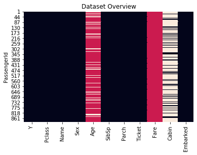

```
 Categerocial   Numeric   NaN
```

```python
'''
Recognize whether a column is numerical or categorical.
:parameter
    :param dtf: dataframe - input data
    :param col: str - name of the column to analyze
    :param max_cat: num - max number of unique values to recognize a column as categorical
:return
    "cat" if the column is categorical or "num" otherwise
'''
def utils_recognize_type(dtf, col, max_cat=20):
    if (dtf[col].dtype == "O") | (dtf[col].nunique() < max_cat):
        return "cat"
    else:
        return "num"
dic_cols = {col:utils_recognize_type(dtf, col, max_cat=20) for col in dtf.columns}
heatmap = dtf.isnull()
for k,v in dic_cols.items():
 if v == "num":
   heatmap[k] = heatmap[k].apply(lambda x: 0.5 if x is False else 1)
 else:
   heatmap[k] = heatmap[k].apply(lambda x: 0 if x is False else 1)
sns.heatmap(heatmap, cbar=False).set_title('Dataset Overview')
plt.show()
print("\033[1;37;40m Categerocial ", "\033[1;30;41m Numeric ", "\033[1;30;47m NaN ")
```

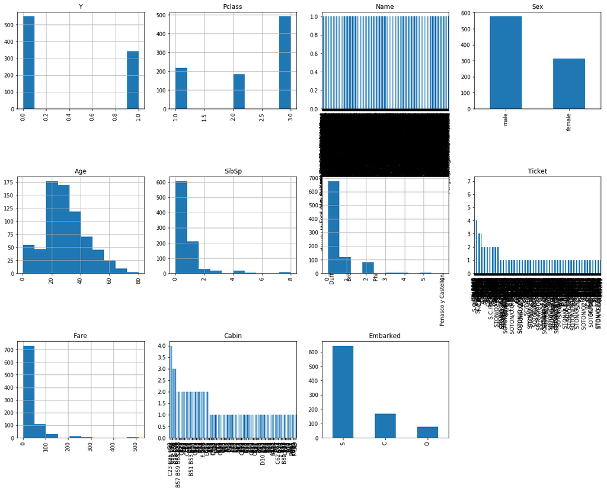

```python
fig = plt.figure(figsize=(20,15))
cols = 4
rows = math.ceil(float(dtf.shape[1]) / cols)
for i, column in enumerate(dtf.columns):
    ax = fig.add_subplot(rows, cols, i + 1)
    ax.set_title(column)
    if dtf.dtypes[column] == np.object:
        dtf[column].value_counts().plot(kind="bar", axes=ax)
    else:
        dtf[column].hist(axes=ax)
        plt.xticks(rotation="vertical")
plt.subplots_adjust(hspace=0.7, wspace=0.2)
```

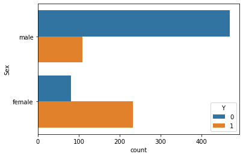

```python
sns.countplot(y='Sex', hue='Y', data=dtf,)
```

###### Do they apply "Save women and children first" ? Explain your answer

make the same analysis done above on these features

```python
# first we gonna fill the null values
print (pd.isnull(dtf).sum())
dtf = dtf.fillna({"Embarked": "S"})#because S is the most common
print('--------after----------')
print (pd.isnull(dtf).sum())
# now we gonna try to fill the age null values using the Name feature
dtf['Name'] = dtf['Name'].map(lambda x: x.split(',')[1].split('.')[0].strip())
titles = dtf['Name'].unique()
print(titles)
print(f'length of tiles {len(titles)}')
```

```
Y             0
Pclass        0
Name          0
Sex           0
Age         177
SibSp         0
Parch         0
Ticket        0
Fare          0
Cabin       687
Embarked      2
dtype: int64
--------after----------
Y             0
Pclass        0
Name          0
Sex           0
Age         177
SibSp         0
Parch         0
Ticket        0
Fare          0
Cabin       687
Embarked      0
dtype: int64
['Mr' 'Mrs' 'Miss' 'Master' 'Don' 'Rev' 'Dr' 'Mme' 'Ms' 'Major' 'Lady'
 'Sir' 'Mlle' 'Col' 'Capt' 'the Countess' 'Jonkheer']
length of tiles 17
```

```python
# the best soloution is to calculate the median for each name-prefix from the 17 above
# and but in the age column
dtf['Age'].fillna(-1, inplace=True)
medians = dict()
for title in titles:
    median = dtf.Age[(dtf["Age"] != -1) & (dtf['Name'] == title)].median()
    medians[title] = median

for index, row in dtf.iterrows():
    if row['Age'] == -1:
        dtf.loc[index, 'Age'] = medians[row['Name']]
print (pd.isnull(dtf).sum())
```

```
Y             0
Pclass        0
Name          0
Sex           0
Age           0
SibSp         0
Parch         0
Ticket        0
Fare          0
Cabin       687
Embarked      0
dtype: int64
```

```python
# YOUR CODE HERE ..

# add feature to check if the passenger is child or adult
lis=[]
for item in dtf['Age']:
    if(item >18):
        lis.append(0)
    else:
        lis.append(1)
dtf['isChild'] =lis
```

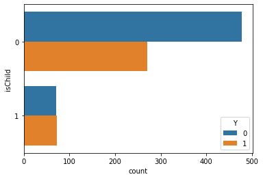

```python
sns.countplot(y='isChild', hue='Y', data=dtf,)
```

### YOUR Answer HERE ..

we notice that about half of the kids died, but only about 25% of the females died It's save the Woman not the children :(

###### Wealth? Ticket, Fare

are rich people saved first? make the same analysis done above on these features

```python
# iam gonna try to make rich feature using the ticket fare
lis = []
for item in dtf['Fare']:
    if item > dtf['Fare'].mean() :
        lis.append(1)
    else:
        lis.append(0)

dtf['isRich'] = lis
dtf
```

| PassengerId | Y | Pclass | Name | Sex | Age | SibSp | Parch | Ticket | Fare | Cabin | Embarked | isChild | isRich |
| --- | --- | --- | --- | --- | --- | --- | --- | --- | --- | --- | --- | --- | --- |
| 1 | 0 | 3 | Mr | male | 22.0 | 1 | 0 | A/5 21171 | 7.2500 | NaN | S | 0 | 0 |
| 2 | 1 | 1 | Mrs | female | 38.0 | 1 | 0 | PC 17599 | 71.2833 | C85 | C | 0 | 1 |
| 3 | 1 | 3 | Miss | female | 26.0 | 0 | 0 | STON/O2. 3101282 | 7.9250 | NaN | S | 0 | 0 |
| 4 | 1 | 1 | Mrs | female | 35.0 | 1 | 0 | 113803 | 53.1000 | C123 | S | 0 | 1 |
| 5 | 0 | 3 | Mr | male | 35.0 | 0 | 0 | 373450 | 8.0500 | NaN | S | 0 | 0 |
| 6 | 0 | 3 | Mr | male | 30.0 | 0 | 0 | 330877 | 8.4583 | NaN | Q | 0 | 0 |
| 7 | 0 | 1 | Mr | male | 54.0 | 0 | 0 | 17463 | 51.8625 | E46 | S | 0 | 1 |
| 8 | 0 | 3 | Master | male | 2.0 | 3 | 1 | 349909 | 21.0750 | NaN | S | 1 | 0 |
| 9 | 1 | 3 | Mrs | female | 27.0 | 0 | 2 | 347742 | 11.1333 | NaN | S | 0 | 0 |
| 10 | 1 | 2 | Mrs | female | 14.0 | 1 | 0 | 237736 | 30.0708 | NaN | C | 1 | 0 |
| 11 | 1 | 3 | Miss | female | 4.0 | 1 | 1 | PP 9549 | 16.7000 | G6 | S | 1 | 0 |
| 12 | 1 | 1 | Miss | female | 58.0 | 0 | 0 | 113783 | 26.5500 | C103 | S | 0 | 0 |
| 13 | 0 | 3 | Mr | male | 20.0 | 0 | 0 | A/5. 2151 | 8.0500 | NaN | S | 0 | 0 |
| 14 | 0 | 3 | Mr | male | 39.0 | 1 | 5 | 347082 | 31.2750 | NaN | S | 0 | 0 |
| 15 | 0 | 3 | Miss | female | 14.0 | 0 | 0 | 350406 | 7.8542 | NaN | S | 1 | 0 |
| 16 | 1 | 2 | Mrs | female | 55.0 | 0 | 0 | 248706 | 16.0000 | NaN | S | 0 | 0 |
| 17 | 0 | 3 | Master | male | 2.0 | 4 | 1 | 382652 | 29.1250 | NaN | Q | 1 | 0 |
| 18 | 1 | 2 | Mr | male | 30.0 | 0 | 0 | 244373 | 13.0000 | NaN | S | 0 | 0 |
| 19 | 0 | 3 | Mrs | female | 31.0 | 1 | 0 | 345763 | 18.0000 | NaN | S | 0 | 0 |
| 20 | 1 | 3 | Mrs | female | 35.0 | 0 | 0 | 2649 | 7.2250 | NaN | C | 0 | 0 |
| 21 | 0 | 2 | Mr | male | 35.0 | 0 | 0 | 239865 | 26.0000 | NaN | S | 0 | 0 |
| 22 | 1 | 2 | Mr | male | 34.0 | 0 | 0 | 248698 | 13.0000 | D56 | S | 0 | 0 |
| 23 | 1 | 3 | Miss | female | 15.0 | 0 | 0 | 330923 | 8.0292 | NaN | Q | 1 | 0 |
| 24 | 1 | 1 | Mr | male | 28.0 | 0 | 0 | 113788 | 35.5000 | A6 | S | 0 | 1 |
| 25 | 0 | 3 | Miss | female | 8.0 | 3 | 1 | 349909 | 21.0750 | NaN | S | 1 | 0 |
| 26 | 1 | 3 | Mrs | female | 38.0 | 1 | 5 | 347077 | 31.3875 | NaN | S | 0 | 0 |
| 27 | 0 | 3 | Mr | male | 30.0 | 0 | 0 | 2631 | 7.2250 | NaN | C | 0 | 0 |
| 28 | 0 | 1 | Mr | male | 19.0 | 3 | 2 | 19950 | 263.0000 | C23 C25 C27 | S | 0 | 1 |
| 29 | 1 | 3 | Miss | female | 21.0 | 0 | 0 | 330959 | 7.8792 | NaN | Q | 0 | 0 |
| 30 | 0 | 3 | Mr | male | 30.0 | 0 | 0 | 349216 | 7.8958 | NaN | S | 0 | 0 |
| ... | ... | ... | ... | ... | ... | ... | ... | ... | ... | ... | ... | ... | ... |
| 862 | 0 | 2 | Mr | male | 21.0 | 1 | 0 | 28134 | 11.5000 | NaN | S | 0 | 0 |
| 863 | 1 | 1 | Mrs | female | 48.0 | 0 | 0 | 17466 | 25.9292 | D17 | S | 0 | 0 |
| 864 | 0 | 3 | Miss | female | 21.0 | 8 | 2 | CA. 2343 | 69.5500 | NaN | S | 0 | 1 |
| 865 | 0 | 2 | Mr | male | 24.0 | 0 | 0 | 233866 | 13.0000 | NaN | S | 0 | 0 |
| 866 | 1 | 2 | Mrs | female | 42.0 | 0 | 0 | 236852 | 13.0000 | NaN | S | 0 | 0 |
| 867 | 1 | 2 | Miss | female | 27.0 | 1 | 0 | SC/PARIS 2149 | 13.8583 | NaN | C | 0 | 0 |
| 868 | 0 | 1 | Mr | male | 31.0 | 0 | 0 | PC 17590 | 50.4958 | A24 | S | 0 | 1 |
| 869 | 0 | 3 | Mr | male | 30.0 | 0 | 0 | 345777 | 9.5000 | NaN | S | 0 | 0 |
| 870 | 1 | 3 | Master | male | 4.0 | 1 | 1 | 347742 | 11.1333 | NaN | S | 1 | 0 |
| 871 | 0 | 3 | Mr | male | 26.0 | 0 | 0 | 349248 | 7.8958 | NaN | S | 0 | 0 |
| 872 | 1 | 1 | Mrs | female | 47.0 | 1 | 1 | 11751 | 52.5542 | D35 | S | 0 | 1 |
| 873 | 0 | 1 | Mr | male | 33.0 | 0 | 0 | 695 | 5.0000 | B51 B53 B55 | S | 0 | 0 |
| 874 | 0 | 3 | Mr | male | 47.0 | 0 | 0 | 345765 | 9.0000 | NaN | S | 0 | 0 |
| 875 | 1 | 2 | Mrs | female | 28.0 | 1 | 0 | P/PP 3381 | 24.0000 | NaN | C | 0 | 0 |
| 876 | 1 | 3 | Miss | female | 15.0 | 0 | 0 | 2667 | 7.2250 | NaN | C | 1 | 0 |
| 877 | 0 | 3 | Mr | male | 20.0 | 0 | 0 | 7534 | 9.8458 | NaN | S | 0 | 0 |
| 878 | 0 | 3 | Mr | male | 19.0 | 0 | 0 | 349212 | 7.8958 | NaN | S | 0 | 0 |
| 879 | 0 | 3 | Mr | male | 30.0 | 0 | 0 | 349217 | 7.8958 | NaN | S | 0 | 0 |
| 880 | 1 | 1 | Mrs | female | 56.0 | 0 | 1 | 11767 | 83.1583 | C50 | C | 0 | 1 |
| 881 | 1 | 2 | Mrs | female | 25.0 | 0 | 1 | 230433 | 26.0000 | NaN | S | 0 | 0 |
| 882 | 0 | 3 | Mr | male | 33.0 | 0 | 0 | 349257 | 7.8958 | NaN | S | 0 | 0 |
| 883 | 0 | 3 | Miss | female | 22.0 | 0 | 0 | 7552 | 10.5167 | NaN | S | 0 | 0 |
| 884 | 0 | 2 | Mr | male | 28.0 | 0 | 0 | C.A./SOTON 34068 | 10.5000 | NaN | S | 0 | 0 |
| 885 | 0 | 3 | Mr | male | 25.0 | 0 | 0 | SOTON/OQ 392076 | 7.0500 | NaN | S | 0 | 0 |
| 886 | 0 | 3 | Mrs | female | 39.0 | 0 | 5 | 382652 | 29.1250 | NaN | Q | 0 | 0 |
| 887 | 0 | 2 | Rev | male | 27.0 | 0 | 0 | 211536 | 13.0000 | NaN | S | 0 | 0 |
| 888 | 1 | 1 | Miss | female | 19.0 | 0 | 0 | 112053 | 30.0000 | B42 | S | 0 | 0 |
| 889 | 0 | 3 | Miss | female | 21.0 | 1 | 2 | W./C. 6607 | 23.4500 | NaN | S | 0 | 0 |
| 890 | 1 | 1 | Mr | male | 26.0 | 0 | 0 | 111369 | 30.0000 | C148 | C | 0 | 0 |
| 891 | 0 | 3 | Mr | male | 32.0 | 0 | 0 | 370376 | 7.7500 | NaN | Q | 0 | 0 |

891 rows × 13 columns

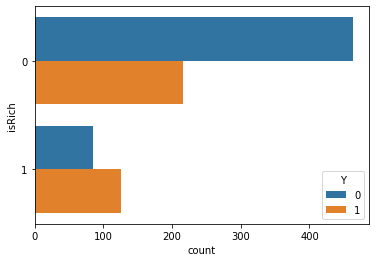

```python
# YOUR Answer HERE ..
sns.countplot(y='isRich', hue='Y', data=dtf,)
```

### Feature Engineering

It’s time to create new features from raw data using domain knowledge. I will provide one example: Let us ll try to create a useful feature by extracting information from the Cabin column. I’m assuming that the letter at the beginning of each cabin number (i.e. “B96”) indicates some the section. lets make a new feature called section taking only the first letter (We can drop the "Cabin_section" column later.

```python
print ("\n*******Count********")
print (dtf.count())
```

```
*******Count********
Y           891
Pclass      891
Name        891
Sex         891
Age         891
SibSp       891
Parch       891
Ticket      891
Fare        891
Cabin       204
Embarked    891
isChild     891
isRich      891
dtype: int64
```

### i think the passengers with same class my be in the same section

```python
## Create new column
dtf['Cabin'].fillna(-1,inplace=True)
dtf["Cabin_section"] = dtf["Cabin"].apply(lambda x: str(x)[0])
```

what are the features that you think are useless or bad? why?

# YOUR Answer HERE ..

mostly Name,Ticket,PasenggerId,Cabin_section and Cabin

remove them from your data frame, keep only good features remember you can seletct colums from dataframe by specifing there names example: new_df = dtf[["Age", "Sex"]]

| PassengerId | Y | Pclass | Name | Sex | Age | SibSp | Parch | Ticket | Fare | Cabin | Embarked | isChild | isRich | Cabin_section |
| --- | --- | --- | --- | --- | --- | --- | --- | --- | --- | --- | --- | --- | --- | --- |
| 1 | 0 | 3 | Mr | male | 22.0 | 1 | 0 | A/5 21171 | 7.2500 | -1 | S | 0 | 0 | - |
| 2 | 1 | 1 | Mrs | female | 38.0 | 1 | 0 | PC 17599 | 71.2833 | C85 | C | 0 | 1 | C |
| 3 | 1 | 3 | Miss | female | 26.0 | 0 | 0 | STON/O2. 3101282 | 7.9250 | -1 | S | 0 | 0 | - |
| 4 | 1 | 1 | Mrs | female | 35.0 | 1 | 0 | 113803 | 53.1000 | C123 | S | 0 | 1 | C |
| 5 | 0 | 3 | Mr | male | 35.0 | 0 | 0 | 373450 | 8.0500 | -1 | S | 0 | 0 | - |

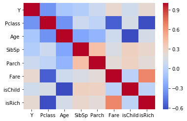

```python
sns.heatmap(dtf.corr(),cmap='coolwarm')
dtf.head()
```

```python
# YOUR CODE HERE ..

newDtf = dtf[["Y","Pclass","Sex","Age","SibSp","Parch","Fare","Embarked","isChild","isRich"]]

newDtf.head()
# 	Y	Pclass	Name	Sex	Age	SibSp	Parch	Ticket	Fare	Cabin	Embarked	isChild	isRich	Cabin_section
```

| PassengerId | Y | Pclass | Sex | Age | SibSp | Parch | Fare | Embarked | isChild | isRich |
| --- | --- | --- | --- | --- | --- | --- | --- | --- | --- | --- |
| 1 | 0 | 3 | male | 22.0 | 1 | 0 | 7.2500 | S | 0 | 0 |
| 2 | 1 | 1 | female | 38.0 | 1 | 0 | 71.2833 | C | 0 | 1 |
| 3 | 1 | 3 | female | 26.0 | 0 | 0 | 7.9250 | S | 0 | 0 |
| 4 | 1 | 1 | female | 35.0 | 1 | 0 | 53.1000 | S | 0 | 1 |
| 5 | 0 | 3 | male | 35.0 | 0 | 0 | 8.0500 | S | 0 | 0 |

## some preprocess for me

```python
# male: 0 , female: 1
lis = []
for item in newDtf['Sex']:
    if item == 'male':
        lis.append(0)
    else:
        lis.append(1)
newDtf['Sex'] = lis
```

```python
# since we dont care if he is traveling with sibling or parent iam gonna make them one feature
travelBuds =newDtf["SibSp"]+newDtf["Parch"]
newDtf['TravelAlone']=np.where(travelBuds >0, 0, 1)

newDtf.drop('SibSp', axis=1, inplace=True)
newDtf.drop('Parch', axis=1, inplace=True)
newDtf.head()
```

| PassengerId | Y | Pclass | Sex | Age | Fare | Embarked | isChild | isRich | TravelAlone |
| --- | --- | --- | --- | --- | --- | --- | --- | --- | --- |
| 1 | 0 | 3 | 0 | 22.0 | 7.2500 | S | 0 | 0 | 0 |
| 2 | 1 | 1 | 1 | 38.0 | 71.2833 | C | 0 | 1 | 0 |
| 3 | 1 | 3 | 1 | 26.0 | 7.9250 | S | 0 | 0 | 1 |
| 4 | 1 | 1 | 1 | 35.0 | 53.1000 | S | 0 | 1 | 0 |
| 5 | 0 | 3 | 0 | 35.0 | 8.0500 | S | 0 | 0 | 1 |

###### Summary

```
Y              0
Pclass         0
Sex            0
Age            0
Fare           0
Embarked       0
isChild        0
isRich         0
TravelAlone    0
dtype: int64
```

| PassengerId | Y | Pclass | Sex | Age | Fare | Embarked | isChild | isRich | TravelAlone |
| --- | --- | --- | --- | --- | --- | --- | --- | --- | --- |
| 1 | 0 | 3 | 0 | 22.0 | 7.2500 | S | 0 | 0 | 0 |
| 2 | 1 | 1 | 1 | 38.0 | 71.2833 | C | 0 | 1 | 0 |
| 3 | 1 | 3 | 1 | 26.0 | 7.9250 | S | 0 | 0 | 1 |
| 4 | 1 | 1 | 1 | 35.0 | 53.1000 | S | 0 | 1 | 0 |
| 5 | 0 | 3 | 0 | 35.0 | 8.0500 | S | 0 | 0 | 1 |

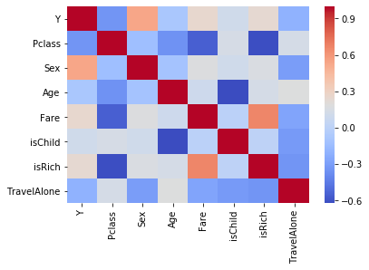

```python
sns.heatmap(newDtf.corr(),cmap='coolwarm')
print(pd.isna(newDtf).sum())
newDtf.head()
```

### new the data is ready to train and the ML things:)

*Now let's get our `X` and `y` numpy arries to use them for training*

```python
# Your code here
encoded_data = newDtf
# features = encoded_data.loc[:,'from_feature???':'to_feature????']
# target = encoded_data.loc[:,'target_feature???']

features = dtf.loc[:,'Pclass':'Cabin_section']
target = dtf.loc[:,'Y']
X_unprocessed = features.values
y_unprocessed = target.values

target_names = dtf.Y.unique()
features_names = dtf.columns
#####################
features1 = encoded_data.loc[:,'Pclass':'TravelAlone']
target1 = encoded_data.loc[:,'Y']

X_processed = features1.values
y_processed = target1.values

target_names1 = encoded_data.Y.unique()
features_names1 = encoded_data.columns




print("X.shape: {}  y.shape: {}".format(X_unprocessed.shape, y_unprocessed.shape))

print("features names: {}".format(list(features_names)))
print("target names: {} ".format(target_names))


print("X.shape: {}  y.shape: {}".format(X_processed.shape, y_processed.shape))

print("features names: {}".format(list(features_names1)))
print("target names: {} ".format(target_names1))
```

```
X.shape: (891, 13)  y.shape: (891,)
features names: ['Y', 'Pclass', 'Name', 'Sex', 'Age', 'SibSp', 'Parch', 'Ticket', 'Fare', 'Cabin', 'Embarked', 'isChild', 'isRich', 'Cabin_section']
target names: [0 1]
X.shape: (891, 8)  y.shape: (891,)
features names: ['Y', 'Pclass', 'Sex', 'Age', 'Fare', 'Embarked', 'isChild', 'isRich', 'TravelAlone']
target names: [0 1]
```

### 2 - Preprocessing

Data preprocessing is the phase of preparing the raw data to make it suitable for a machine learning model.

# IMPORTANT NOTE

use Piplines to each step

###### To do:

- Treat missings
- Encode categorical data
- Scaling
- Dataset split

###### Missing values

Drop nan values or replace missing values with values useing `Imputer`, with a strategy of your choise (`mean`, `median`,...) and explain which is better

# YOUR CODE HERE ..

Already handeled the NaN in above sections search for it

###### Categorical Encoding

Use `sklearn.preprocessing.OneHotEncoder` or `sklearn.preprocessing.OneHotEncoder` to encode categorical features. and then compare them and explain why Label encoder is not good

*Encode your data*

[output not shown]

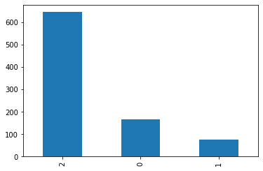

```python
# YOUR CODE HERE ..
from sklearn.preprocessing import LabelEncoder
labelencoder_Y = LabelEncoder()
Y = labelencoder_Y.fit_transform(encoded_data['Embarked'])
encoded_data2  = encoded_data
encoded_data2['Embarked']=Y
encoded_data2.Embarked.value_counts().plot(kind='bar')
```

### since the labelEncoder gives 2 to the most common 'S' value

it will make the data impalanced with high rates

```python
# for the Embarked column
# since S is the most frequent iam gonna  give it the less number and so on
lis= []
for item in encoded_data['Embarked']:
    if item == 'S':
        lis.append(1)
    elif item == 'C':
        lis.append(2)
    else:
        lis.append(3)
encoded_data['Embarked']=lis
encoded_data.head()
```

| PassengerId | Y | Pclass | Sex | Age | Fare | Embarked | isChild | isRich | TravelAlone |
| --- | --- | --- | --- | --- | --- | --- | --- | --- | --- |
| 1 | 0 | 3 | 0 | 22.0 | 7.2500 | 1 | 0 | 0 | 0 |
| 2 | 1 | 1 | 1 | 38.0 | 71.2833 | 2 | 0 | 1 | 0 |
| 3 | 1 | 3 | 1 | 26.0 | 7.9250 | 1 | 0 | 0 | 1 |
| 4 | 1 | 1 | 1 | 35.0 | 53.1000 | 1 | 0 | 1 | 0 |
| 5 | 0 | 3 | 0 | 35.0 | 8.0500 | 1 | 0 | 0 | 1 |

```python
features1 = encoded_data.loc[:,'Pclass':'TravelAlone']
target1 = encoded_data.loc[:,'Y']

X_processed = features1.values
y_processed = target1.values

target_names1 = encoded_data.Y.unique()
features_names1 = encoded_data.columns

print("X.shape: {}  y.shape: {}".format(X_processed.shape, y_processed.shape))

print("features names: {}".format(list(features_names1)))
print("target names: {} ".format(target_names1))
```

```
X.shape: (891, 8)  y.shape: (891,)
features names: ['Y', 'Pclass', 'Sex', 'Age', 'Fare', 'Embarked', 'isChild', 'isRich', 'TravelAlone']
target names: [0 1]
```

```python
X_processed[0]
```

```
array([ 3.  ,  0.  , 22.  ,  7.25,  1.  ,  0.  ,  0.  ,  0.  ])
```

###### Scaling

*Feature Scaling*

**Use Feature scaling to standardize the range of features of your data.**

*choose one method of scaling*

```python
from sklearn.preprocessing import StandardScaler,RobustScaler, MinMaxScaler,  Normalizer

from sklearn.preprocessing import StandardScaler

sc = StandardScaler()
X_processed = sc.fit_transform(X_processed)
```

###### Spliting

```python
from sklearn.model_selection import train_test_split
# YOUR CODE HERE ..

X_train, X_test, y_train, y_test = train_test_split(X_processed, y_processed, test_size=0.25,
                                                    random_state=1)
```

### 3 - Model Selection & Feature Selection

###### Plan:

1- build baseline model

2- Feature Selection:

```
 by correlation, by importance
```

3- Model selecion (Choosing a classifier) :

```
 try differnt classification methods (single classifiers as well as ensemble ones) and print thier auc socre
 use grid search to find the best paramters for the model (the whole pipline) that give you good results
```

###### Baseline model

*implement `train_and_test` that trains and tests the dataset with features X and target y, using classifier*

- train classifer on training data
- predict on testing data
- print confution matirx
- print accuracy score
- print roc auc (use Target score as probability estimates of the positive class (classifier.predict_proba(X_test)[:,1]), instead of decision_function)
- print classification report
- print roc curve

```python
from sklearn.metrics import confusion_matrix
from sklearn.metrics import accuracy_score
from sklearn.metrics import roc_auc_score, roc_curve
from sklearn.metrics import classification_report


def train_and_test(classifier, X_train, X_test, y_train, y_test):
    classifier.fit(X_train, y_train)
    y_pred = classifier.predict(X_test)
    y_score = classifier.predict_proba(X_test)[:,1]

    fpr, tpr, _ = roc_curve(y_test, y_score)

    accuracy = accuracy_score(y_test, y_pred)
    roc_auc = roc_auc_score(fpr, tpr)
    classification_rep =classification_report(y_test, y_pred, target_names=['~surv', 'surv'])
    con_matrix =confusion = confusion_matrix(y_test, y_pred)


    # ploting confustion matrix
    plt.figure(figsize=(12,12))
    plt.subplot(2,1,1)
    sns.heatmap(con_matrix, annot=True, fmt="d", xticklabels=target_names, yticklabels=target_names)
    plt.ylabel("Real value")
    plt.xlabel("Predicted value")
    plt.show()

    # print scores
    print ("accuracy  score: {} %".format(accuracy))
    print ("auc  score: {} ".format(roc_auc))
    print(classification_rep)

    # print ROC curve
    plt.figure()
    plt.plot(fpr, tpr, color='darkorange',
         lw=2, label='ROC curve (area = %0.2f)' % roc_auc)
    plt.plot([0, 1], [0, 1], color='navy', lw=2, linestyle='--')
    plt.xlim([0.0, 1.0])
    plt.ylim([0.0, 1.05])
    plt.xlabel('False Positive Rate')
    plt.ylabel('True Positive Rate')
    plt.title('Receiver operating characteristic example')
    plt.legend(loc="lower right")
    plt.show()
```

baseline model

```python
from sklearn.linear_model import LogisticRegression
lrclf = LogisticRegression()

lrclf.fit(X_train,y_train)
print ("Train set accurecy: {:.2f} ".format(lrclf.score(X_train,y_train)))
print ("Test set accurecy: {:.2f} ".format(lrclf.score(X_test,y_test)))
```

```
Train set accurecy: 0.82
Test set accurecy: 0.78
```

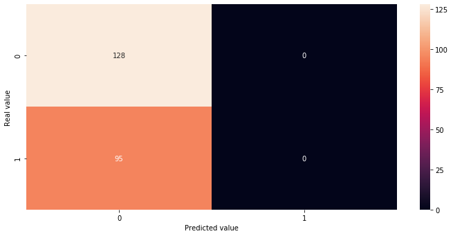

```
accuracy  score: 0.5739910313901345 %
auc  score: 1.0
              precision    recall  f1-score   support

       ~surv       0.57      1.00      0.73       128
        surv       0.00      0.00      0.00        95

    accuracy                           0.57       223
   macro avg       0.29      0.50      0.36       223
weighted avg       0.33      0.57      0.42       223
```

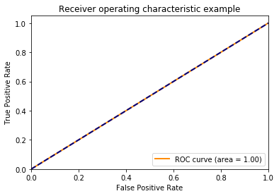

```python
# YOUR CODE HERE ..
# train_and_test(model, X_train, X_test, y_train, y_test)
from sklearn.dummy import DummyClassifier
dummy_majority = DummyClassifier(strategy = 'most_frequent')

train_and_test(dummy_majority, X_train, X_test, y_train, y_test)
```

*How good is your classifier (compare precion and recall, comment on accuracy, roc and auc).*